# Beyond Metabarcoding: Community Ecology

Jayde MacMillan 20068250  
[github-jaydealexandra](https://github.com/jaydealexandra/Metabarcoding)  
March 16 2022

## Introduction

Metabarcoding is the barcoding of DNA or RNA that allows taxonomic identification on a large scale. This method provides a fast and efficient way of identifying many organisms within a specific area [Westfall et al., 2019](https://pubmed.ncbi.nlm.nih.gov/31657513/). As invasive species continue to spread, the use of metabarcoding as a biosurveillance tool can be utilized to detect and manage these species.

Garlic mustard, *Alliaria petiolata* is an invasive species native to Europe. If left unmanaged, it can displace other native wildflowers and interfere with the growth of species of fungi [(Garlic Mustard | Ontario’s Invading Species Awareness Program, 2021)](http://www.invadingspecies.com/invaders/plants/garlic-mustard/)

Using a floristic survey from Queen’s University Biological Station (QUBS), we will address two questions:  
1. Does garlic mustard effect the plant community?  
2. Does either the presence or absence of garlic mustard have a stronger effect on the sampling population?

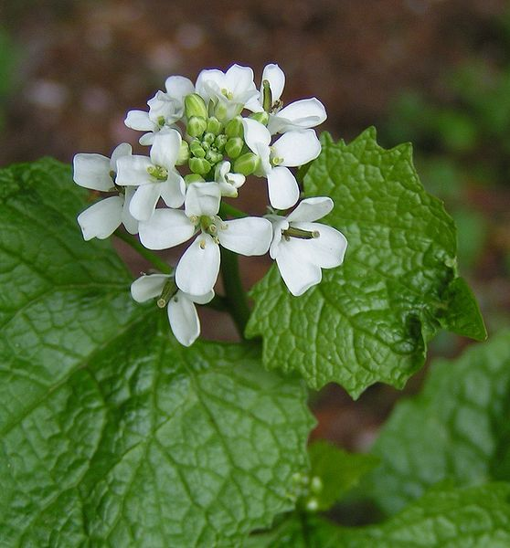

Figure 1. A photo of garlic mustard.[(Garlic Mustard - Ontario Invasive Plant Council, 2021)](https://www.ontarioinvasiveplants.ca/invasive-plants/species/garlic-mustard/)

## Setup

```r
#loads the required packages
library(ggplot2)
library(ape)
library(ggtree)
library(vegan)
library(dplyr)
library(reshape2)
```

```r
#imports data into an object
floristicSurvey <- read.csv("FloristicSurvey.csv", header = T, fileEncoding="UTF-8-BOM")

#selects only the species
floristicSpec <- select(floristicSurvey, Claytonia_virginiana:maianthenum_racemosum)

#creates a data frame of the species and sets the row names to the
floristicSub <- data.frame(floristicSpec, row.names = floristicSurvey$Quadrate)
```

## Bray-Curtis Dissimilarity

The [Bray-Curtis Dissimilarity](https://en.wikipedia.org/wiki/Bray%E2%80%93Curtis_dissimilarity) is used to count the ecological distance between two sites based on the number of occurrences at each site.

```r
florDist <- vegdist(floristicSub, method = "bray", binary = F)
```

## Neighbour Joining Method

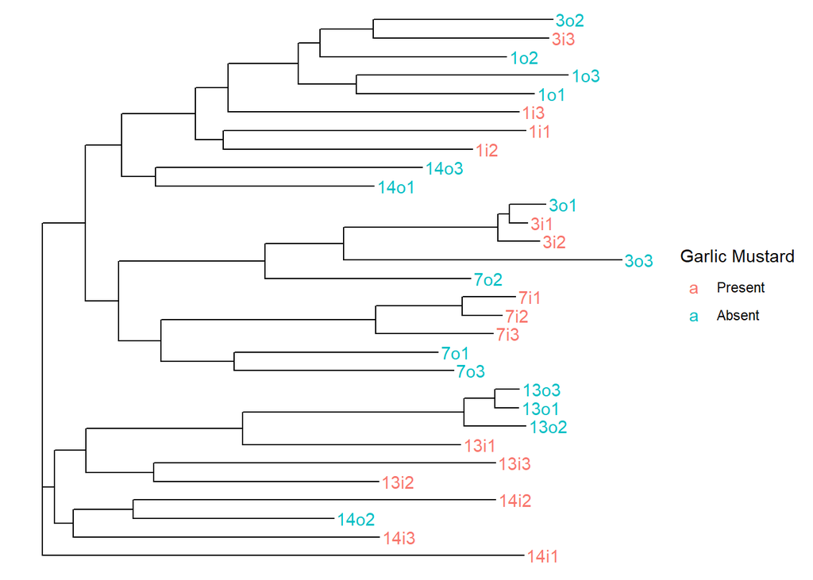

```r
#performs a neighbour joining tree estimation of the dissimilarity index
florTree <- nj(florDist)

#creates a tree
ggtree(florTree, layout="rectangular") %<+% floristicSurvey +
  geom_tiplab(aes(colour= Location)) +
  theme(legend.position="right") +
  scale_colour_discrete(name= "Garlic Mustard", labels = c("Present", "Absent"))
```

## NMDS

```r
set.seed(13)
NMDSdat <- metaMDS(florDist, k=2)
```

```
## *** Solution reached
```

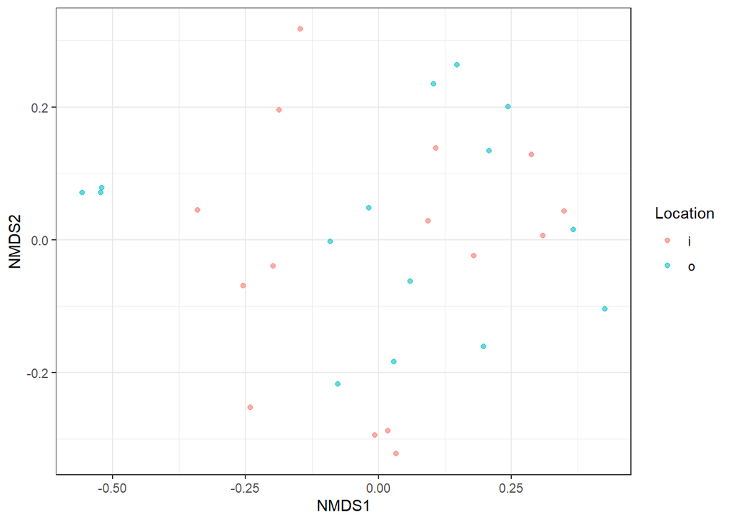

```r
#creates data for plotting
PDat<-data.frame(NMDS1=NMDSdat$points[,1],
                 NMDS2=NMDSdat$points[,2],
                 Quadrate=row.names(floristicSub))

#adds labels using the merge function
PDat<-merge(PDat,floristicSurvey,by="Quadrate",all.x=T,all.y=F)

#creates a plot
qplot(x=NMDS1,y=NMDS2,colour=Location,alpha=I(0.6),data=PDat)+theme_bw()
```